# WMATA Transit System Analysis: Summary Paper

### 4.3 Traffic Flow Optimization Problem

“How can entry and exit pattern analysis at high-traffic stations inform strategic decisions about service adjustments?”

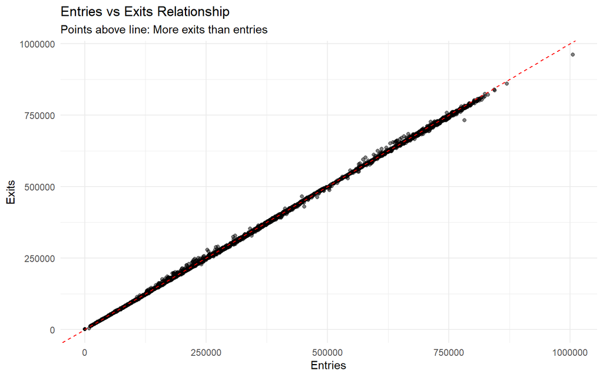

```r
# Basic entry/exit analysis
if("Entries" %in% names(total_entries_exits) && "Exits" %in% names(total_entries_exits)) {
  # Create a new column for entry/exit ratio
  total_entries_exits$EntryExitRatio <- total_entries_exits$Entries / total_entries_exits$Exits

  # Basic summary of the ratio
  summary(total_entries_exits$EntryExitRatio)

  # Simple visualization of entries vs exits
  ggplot(total_entries_exits, aes(x = Entries, y = Exits)) +
    geom_point(alpha = 0.5) +
    geom_abline(slope = 1, intercept = 0, linetype = "dashed", color = "red") +
    labs(title = "Entries vs Exits Relationship",
         subtitle = "Points above line: More exits than entries") +
    theme_minimal()
}
```

## 5. Hypothesis Testing

We formulated testable hypotheses for our key research questions:

### 5.1 Day of Week Differences Hypothesis

**H0**: There is no significant difference in ridership between days of the week.  
**H1**: At least one day of the week has significantly different ridership.

```r
# ANOVA test for day of week differences
if("Day" %in% names(boardings_by_day) && "Boardings" %in% names(boardings_by_day)) {
  # Ensure Day is properly ordered
  day_levels <- c("Sunday", "Monday", "Tuesday", "Wednesday", "Thursday", "Friday", "Saturday")
  boardings_by_day$Day <- factor(boardings_by_day$Day, levels = day_levels)

  # One-way ANOVA
  day_anova <- aov(Boardings ~ Day, data = boardings_by_day)
  cat("ANOVA Results - Testing if ridership differs by day of week:\n")
  print(summary(day_anova))

  # Visualization
  ggplot(boardings_by_day, aes(x = Day, y = Boardings, fill = Day)) +
    geom_bar(stat = "identity") +
    labs(title = "Boardings by Day of Week",
         y = "Average Boardings") +
    theme_minimal() +
    theme(axis.text.x = element_text(angle = 45, hjust = 1),
          legend.position = "none")
}
```

[output not shown]

### 5.2 Time Period Distribution Hypothesis

**H0**: Ridership is evenly distributed across time periods.  
**H1**: Ridership is not evenly distributed across time periods.

```
##
## Chi-square test for equal distribution across time periods:
##
##  Chi-squared test for given probabilities
##
## data:  time_data$Boardings
## X-squared = 156132, df = 4, p-value < 2.2e-16
```

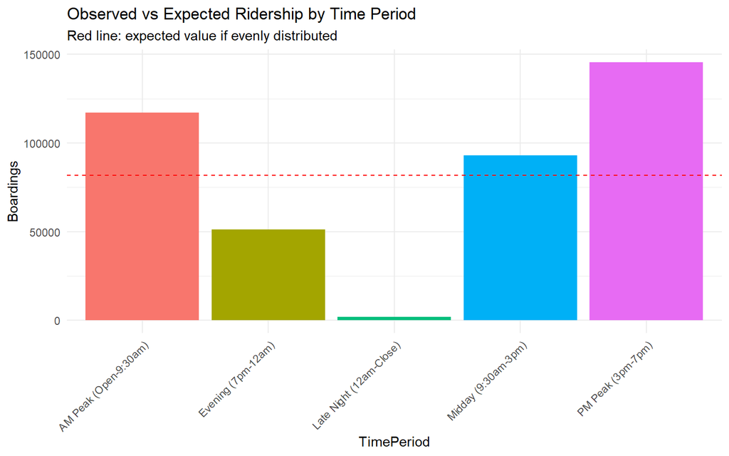

```r
# Chi-square test for time period distribution
if("Station Name" %in% names(boardings_by_route) && exists("time_data")) {
  # Calculate expected values (even distribution)
  time_data$Expected <- sum(time_data$Boardings) / nrow(time_data)

  # Chi-square test
  chi_sq_result <- chisq.test(time_data$Boardings)
  cat("\nChi-square test for equal distribution across time periods:\n")
  print(chi_sq_result)

  # Visualization with expected line
  ggplot(time_data, aes(x = TimePeriod, y = Boardings, fill = TimePeriod)) +
    geom_bar(stat = "identity") +
    geom_hline(yintercept = time_data$Expected[1], linetype = "dashed", color = "red") +
    labs(title = "Observed vs Expected Ridership by Time Period",
         subtitle = "Red line: expected value if evenly distributed",
         y = "Boardings") +
    theme_minimal() +
    theme(axis.text.x = element_text(angle = 45, hjust = 1),
          legend.position = "none")
}
```

### 5.3 AM vs PM Peak Hypothesis

**H0**: There is no significant difference between AM and PM peak ridership.  
**H1**: PM peak ridership is significantly different from AM peak ridership.

```
## AM Peak total boardings: 117,268
## PM Peak total boardings: 145,441
## PM to AM ratio: 1.24
##
## Paired t-test comparing AM vs PM peak ridership:
##
##  Paired t-test
##
## data:  peak_comparison$AM_Peak and peak_comparison$PM_Peak
## t = -1.4626, df = 97, p-value = 0.1468
## alternative hypothesis: true mean difference is not equal to 0
## 95 percent confidence interval:
##  -677.5894  102.6303
## sample estimates:
## mean difference
##       -287.4796
```

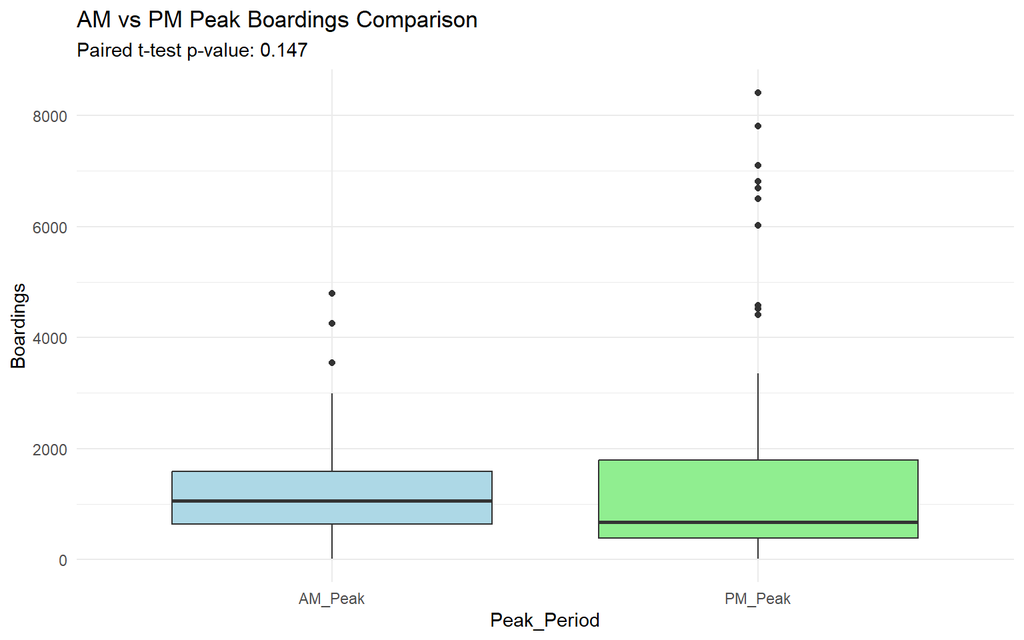

```r
# AM vs PM Peak paired t-test
if("Station Name" %in% names(boardings_by_route)) {
  # Extract AM and PM peak data
  peak_comparison <- data.frame(
    Station = boardings_by_route$`Station Name`,
    AM_Peak = boardings_by_route$`AM Peak (Open-9:30am)`,
    PM_Peak = boardings_by_route$`PM Peak (3pm-7pm)`
  )

  # Calculate system totals
  am_total <- sum(peak_comparison$AM_Peak, na.rm = TRUE)
  pm_total <- sum(peak_comparison$PM_Peak, na.rm = TRUE)

  cat("AM Peak total boardings:", format(am_total, big.mark=","), "\n")
  cat("PM Peak total boardings:", format(pm_total, big.mark=","), "\n")
  cat("PM to AM ratio:", round(pm_total/am_total, 2), "\n")

  # Paired t-test
  t_test_result <- t.test(peak_comparison$AM_Peak, peak_comparison$PM_Peak, paired = TRUE)
  cat("\nPaired t-test comparing AM vs PM peak ridership:\n")
  print(t_test_result)

  # Visualization
  peak_long <- reshape2::melt(peak_comparison[, c("Station", "AM_Peak", "PM_Peak")],
                             id.vars = "Station",
                             variable.name = "Peak_Period",
                             value.name = "Boardings")

  ggplot(peak_long, aes(x = Peak_Period, y = Boardings)) +
    geom_boxplot(fill = c("lightblue", "lightgreen")) +
    labs(title = "AM vs PM Peak Boardings Comparison",
         subtitle = paste("Paired t-test p-value:", format.pval(t_test_result$p.value, digits = 3)),
         y = "Boardings") +
    theme_minimal()
}
```

### 5.4 Station Clustering Analysis

**H0**: Stations do not form distinct clusters based on ridership patterns.  
**H1**: Stations form statistically significant clusters based on ridership patterns.

```
## Distribution of stations across clusters:
##
##  1  2  3
##  8 63 27
##
## Cluster centroids (average ridership patterns):
##           AM Peak (Open-9:30am) Midday (9:30am-3pm) PM Peak (3pm-7pm)
## Cluster 1             1547.8750           2490.5000          6046.125
## Cluster 2              823.6825            540.7143           666.746
## Cluster 3             1962.7037           1450.5926          2039.519
##           Evening (7pm-12am) Late Night (12am-Close)
## Cluster 1          2511.5000               101.62500
## Cluster 2           218.2063                 7.31746
## Cluster 3           646.8889                18.77778
```

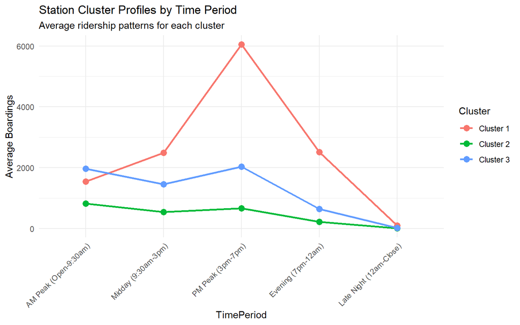

```r
# K-means clustering of stations based on time period patterns
if("Station Name" %in% names(boardings_by_route)) {
  # Prepare data for clustering - use time period columns
  station_patterns <- boardings_by_route[, c("AM Peak (Open-9:30am)",
                                           "Midday (9:30am-3pm)",
                                           "PM Peak (3pm-7pm)",
                                           "Evening (7pm-12am)",
                                           "Late Night (12am-Close)")]

  # Scale the data for better clustering
  station_patterns_scaled <- scale(station_patterns)

  # Determine optimal number of clusters (using 3 for this example)
  k <- 3

  # Perform k-means clustering
  set.seed(123)
  km_result <- kmeans(station_patterns_scaled, centers = k)

  # Add cluster assignment to original data
  station_clusters <- data.frame(
    Station = boardings_by_route$`Station Name`,
    Cluster = as.factor(km_result$cluster)
  )

  # Show distribution of stations across clusters
  cat("Distribution of stations across clusters:\n")
  print(table(station_clusters$Cluster))

  # Calculate cluster centroids
  centroids_scaled <- km_result$centers
  centroids <- t(apply(centroids_scaled, 1, function(x)
    x * apply(station_patterns, 2, sd) + apply(station_patterns, 2, mean)))
  centroids_df <- as.data.frame(centroids)
  rownames(centroids_df) <- paste("Cluster", 1:k)

  cat("\nCluster centroids (average ridership patterns):\n")
  print(centroids_df)

  # Reshape centroids for visualization
  centroids_long <- reshape2::melt(centroids_df,
                                 variable.name = "TimePeriod",
                                 value.name = "Boardings")
  centroids_long$Cluster <- rep(rownames(centroids_df), ncol(centroids_df))

  # Plot cluster profiles
  ggplot(centroids_long, aes(x = TimePeriod, y = Boardings, color = Cluster, group = Cluster)) +
    geom_line(size = 1) +
    geom_point(size = 3) +
    labs(title = "Station Cluster Profiles by Time Period",
         subtitle = "Average ridership patterns for each cluster",
         y = "Average Boardings") +
    theme_minimal() +
    theme(axis.text.x = element_text(angle = 45, hjust = 1))
}
```